# Exploring the BRFSS data

## Setup

### Load packages

```r
library(statsr)
library(dplyr)
library(ggplot2)
library(pander)
library(tidyr)
```

### Load data

Make sure your data and R Markdown files are in the same directory. When loaded your data file will be called `brfss2013`. Delete this note when before you submit your work.

```r
load("brfss2013.RData")
```

## Part 1: Data

The behavioral Risk Factor Surveillance System (BRFSS) is a collaborative project between all of the states in the United States( US) and participating US territories and the Centers for Disease Control and Prevention (CDC). It’s major objective is to collect uniform, state-specific data on preventive health practices and risk behaviors that are linked to chronic diseases, injuries, and preventable infectious diseases that affect the adult population. Now we will dive into some important aspects of our data. * * *

**how data was collected:** The BRFSS was initiated in 1984, with 15 states collecting surveillance data on risk behaviors through monthly telephone interviews. Over time, the number of states participating in the survey increased; by 2001, 50 states, the District of Columbia, Puerto Rico, Guam, and the US Virgin Islands were participating in the BRFSS. Today, all 50 states, the District of Columbia, Puerto Rico, and Guam collect data annually and American Samoa, Federated States of Micronesia, and Palau collect survey data over a limited point- in-time (usually one to three months). In this document, the term “state” is used to refer to all areas participating in BRFSS, including the District of Columbia, Guam, and the Commonwealth of Puerto Rico.

**sample:** Health characteristics estimated from the BRFSS pertain to the non-institutionalized adult population, aged 18 years or older, who reside in the US. In 2013, additional question sets were included as optional modules to provide a measure for several childhood health and wellness indicators, including asthma prevalence for people aged 17 years or younger. **Notes:**

### generabizability

the results from this Data may be general because the dataset is very larg and random somehow with some prorblems the way this data is collected may cause some problems such as non-response bias since this data is collected through telephones and this may skew the data , the data was collected not from documented information but from information that the respondent like to say , so we should look at our data with some skepticism .

### causality

the relations concluded from this study can only lead to a correlation between variables not a causation since this is an observational and Retrospective study

## Part 2: Research questions

**Research quesion 1:** does people with better health sleeps better ? in another words : is there a correlation between sleeping hours and general health ?

**Research quesion 2:** we want to find if there a correlation between education and the number of children and we want to dig more to see if the income also affects . . .

**Research quesion 3:** does income level affect the potentiality of having a depressive disorder ?

## Part 3: Exploratory data analysis

**Research quesion 1:** for this question we will work with two variables 1) number of hours slept —-> sleptim1 2) health level —–> genhlth first of all i will clean my variables from any null values

```r
brfss2013_cleaned <- brfss2013 %>% filter(!is.na(genhlth)) %>%
  filter(!is.na(sleptim1)) %>%
  filter(!is.na(poorhlth))
```

now that i have cleaned my data i will put my variables into a new data frame called my_Data2

```r
my_Data2 <- brfss2013_cleaned %>%
  select(genhlth , sleptim1 , poorhlth)
```

taking a look in the genhlth variable

```r
my_Data2 %>%
  group_by(genhlth) %>%
  summarise(n = n())
```

```
## # A tibble: 5 x 2
##   genhlth       n
##   <fct>     <int>
## 1 Excellent 25816
## 2 Very good 67622
## 3 Good      76818
## 4 Fair      49126
## 5 Poor      24241
```

since our data is ready i will plot a graph for my two variables

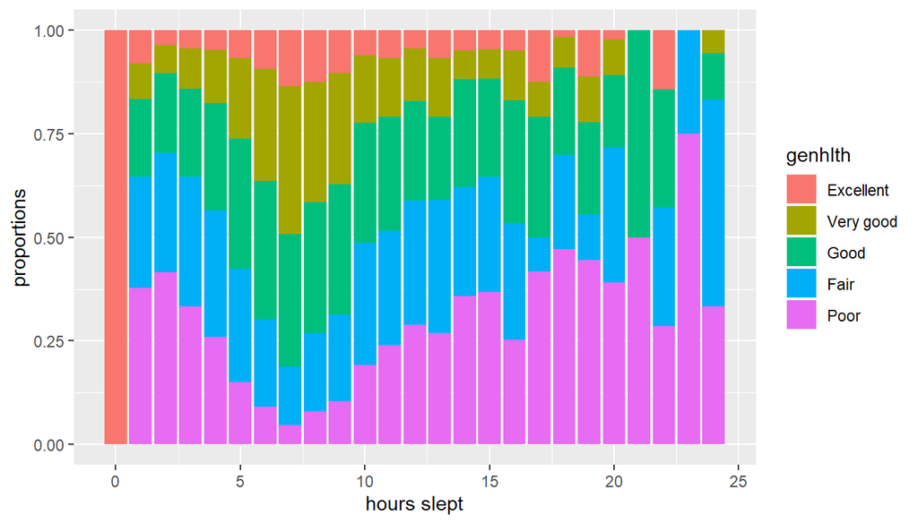

```r
ggplot(data=my_Data2 , aes(sleptim1, fill = genhlth) ) + geom_bar(position = "fill") + xlab("hours slept") + ylab("proportions")
```

here we can see an important trend in our data that people who tend to sleep around 7 hours have better health we can dig more in the summary numbers in our data to see it better, since our data is skewed i will use median to know more about my data

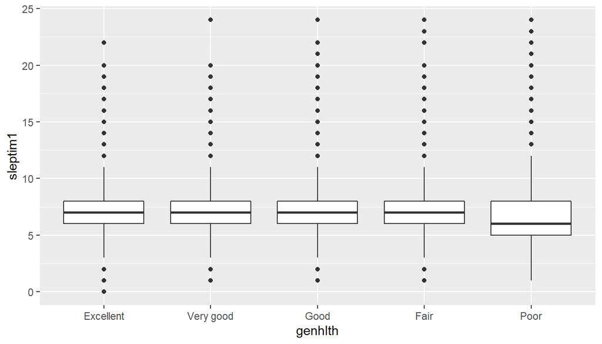

```r
ggplot(data = my_Data2 , aes(x=genhlth , y=sleptim1 )) + geom_boxplot()
```

we can see from the box plot that the people with poor health ranges larger in sleeping hours and we can also see that the median isn’t 7 hours like the other states next i will compute the summary numbers to understand the graphs better

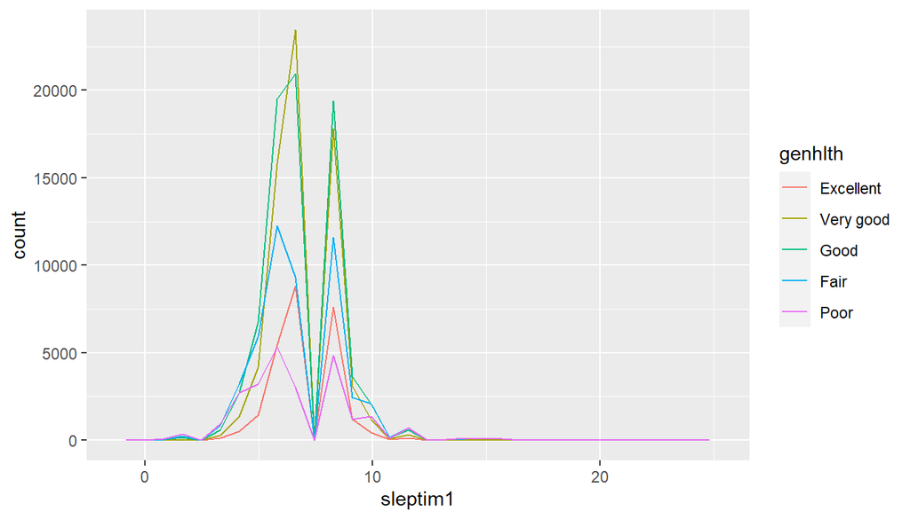

```r
ggplot(data = my_Data2, mapping = aes(x = sleptim1, colour = genhlth)) +
  geom_freqpoly()
```

```r
my_Data2 %>%
  group_by(genhlth) %>%
  summarise( median = median(sleptim1), iqr = IQR(sleptim1 ) , min = min(sleptim1) , max = max(sleptim1) )
```

```
## # A tibble: 5 x 5
##   genhlth   median   iqr   min   max
##   <fct>      <dbl> <dbl> <int> <int>
## 1 Excellent      7     2     0    22
## 2 Very good      7     2     1    24
## 3 Good           7     2     1    24
## 4 Fair           7     2     1    24
## 5 Poor           6     3     1    24
```

here we are creating a new data with our variables only the seleepng hours and the mean of poor health days for every hour

```r
new_Data <- my_Data2 %>%
  group_by(sleeping_hours = as.factor(sleptim1)) %>%
  summarise(poorhealthmean = mean(poorhlth) , count = n())
```

no i will plot my data with the sleeping hours on the x axis and the poor health mean on the y axis

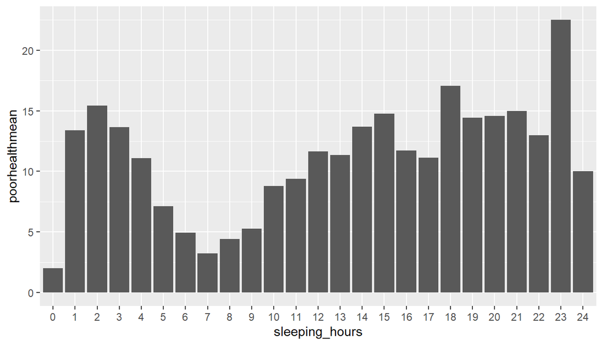

```r
  ggplot(data = new_Data , aes(x=sleeping_hours , y = poorhealthmean)) + geom_bar(stat = "identity")
```

as we can see people who tend to sleep near 7 hours suffers from less poor health days in avergae **Research quesion 2:** we want to find if there a correlation between education and the number of children and we want to dig more to see if the income also affects . . . we will make our data ready and cleaned

```r
brfss2013_cleaned <- brfss2013_cleaned %>%
  filter(!is.na(children)) %>%
  filter(!is.na(income2)) %>%
  filter(!is.na(educa))
```

now i will make a new data frame to wrap up my work

```r
my_Data3 <- brfss2013_cleaned %>%
  select(children , income2 , educa)
```

now i will plot my first two variables the children and last education to see if there a relationship

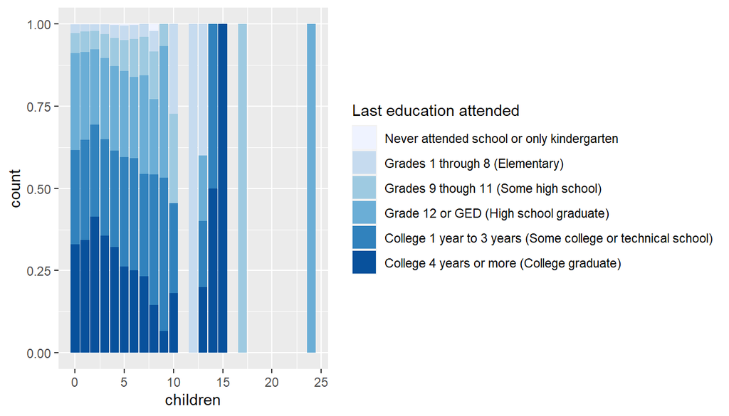

```r
ggplot(data = my_Data3 , aes(children , fill=educa)) + geom_bar(position = "fill") + scale_fill_brewer(name="Last education attended")
```

we want to know more about our data so we will take a look on median and iqr since our data is skewed

```r
my_Data3 %>%
  group_by(educa) %>%
  summarise(median = median(children) , mean = mean(children),  iqr =IQR(children) , n =n())
```

```
## # A tibble: 6 x 5
##   educa                                                 median  mean   iqr     n
##   <fct>                                                  <dbl> <dbl> <dbl> <int>
## 1 Never attended school or only kindergarten                 0 0.882     1   211
## 2 Grades 1 through 8 (Elementary)                            0 0.594     1  5433
## 3 Grades 9 though 11 (Some high school)                      0 0.619     1 12991
## 4 Grade 12 or GED (High school graduate)                     0 0.493     1 59539
## 5 College 1 year to 3 years (Some college or technical~      0 0.572     1 60928
## 6 College 4 years or more (College graduate)                 0 0.600     1 71859
```

it appears that the median number of children is 0 for all categories that isn’t decisive because the reason maybe because of the majorty of respondent don’t have children so let’s see

```r
my_Data3 %>%
  group_by(children) %>%
  summarise(n = n())
```

```
## # A tibble: 17 x 2
##    children      n
##       <int>  <int>
##  1        0 149877
##  2        1  25095
##  3        2  21776
##  4        3   9301
##  5        4   3315
##  6        5   1019
##  7        6    390
##  8        7    103
##  9        8     48
## 10        9     15
## 11       10     11
## 12       12      1
## 13       13      5
## 14       14      2
## 15       15      1
## 16       17      1
## 17       24      1
```

as we already assumed the majority of the respondent doesn’t have children we can exclude those who has no children and try to figure what’s happening

```r
my_Data3_edited <- my_Data3 %>%
  filter(children > 0)
```

let’s remake our plot

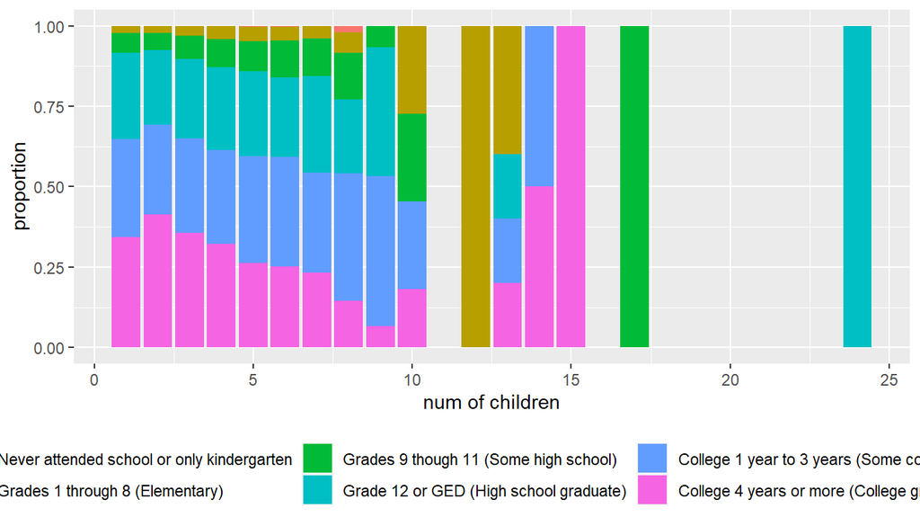

```r
ggplot(data = my_Data3_edited , aes(children , fill=educa)) + geom_bar(position = "fill") + theme(legend.position="bottom") + ylab("proportion") + xlab("num of children")
```

let’s see our numbers

```r
my_Data3_edited %>%
  group_by(educa) %>%
  summarise(median = median(children) , mean = mean(children),  iqr =IQR(children) , n =n())
```

```
## # A tibble: 6 x 5
##   educa                                                 median  mean   iqr     n
##   <fct>                                                  <dbl> <dbl> <dbl> <int>
## 1 Never attended school or only kindergarten                 2  2.14     2    87
## 2 Grades 1 through 8 (Elementary)                            2  2.20     2  1466
## 3 Grades 9 though 11 (Some high school)                      2  2.08     2  3865
## 4 Grade 12 or GED (High school graduate)                     2  1.92     1 15269
## 5 College 1 year to 3 years (Some college or technical~      2  1.94     1 17977
## 6 College 4 years or more (College graduate)                 2  1.92     1 22420
```

it appears that the median is stand still and the mean changes a bit because there is some outliers that would be very interesting cases to study

we can also see that the data varies less the higher education the person have which means that people with higher education tend to have 2 children but people with lower tend to have two or more

now we want to look at our third variable and see how can effect our assumption

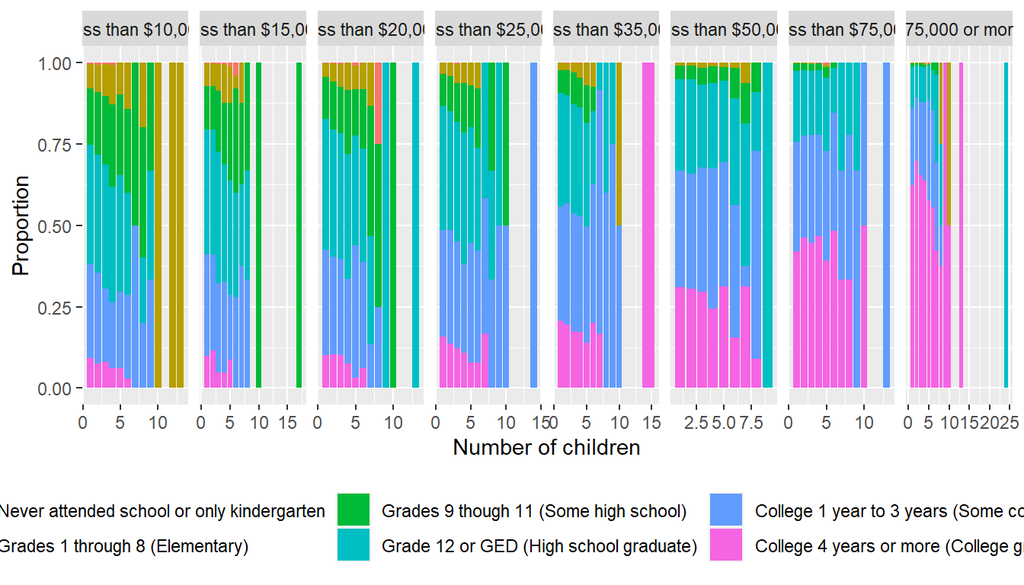

```r
ggplot(data = my_Data3_edited ,  aes(children , fill=educa)) + geom_bar(position = "fill") + facet_grid(.~income2 ,  scales = "free") + theme(legend.position="bottom") + xlab("Number of children") + ylab("Proportion")
```

as income increases we can see that the number of people with higher education increases and people tend to stay a little bit with 2 children for average with no big variance in higher income so let’s look at the numbers

```r
my_Data3_edited %>%
  group_by(income2) %>%
  summarise(median = median(children) , iqr = IQR(children) , n =n() , min = min(children) , max = max(children))
```

```
## # A tibble: 8 x 6
##   income2           median   iqr     n   min   max
##   <fct>              <dbl> <dbl> <int> <int> <int>
## 1 Less than $10,000      2     1  4025     1    13
## 2 Less than $15,000      2     1  3608     1    17
## 3 Less than $20,000      2     2  5047     1    13
## 4 Less than $25,000      2     2  5802     1    14
## 5 Less than $35,000      2     1  6023     1    15
## 6 Less than $50,000      2     1  7673     1     9
## 7 Less than $75,000      2     1  9447     1    13
## 8 $75,000 or more        2     1 19459     1    24
```

this shows our point above and now we will come to a little more detailed summary

```r
my_Data3_edited %>%
  group_by(income2 , educa) %>%
  summarise(median = median(children) , iqr = IQR(children) , n =n())
```

```
## # A tibble: 48 x 5
## # Groups:   income2 [8]
##    income2        educa                                       median   iqr     n
##    <fct>          <fct>                                        <dbl> <dbl> <int>
##  1 Less than $10~ Never attended school or only kindergarten       2     1    24
##  2 Less than $10~ Grades 1 through 8 (Elementary)                  2     2   344
##  3 Less than $10~ Grades 9 though 11 (Some high school)            2     2   772
##  4 Less than $10~ Grade 12 or GED (High school graduate)           2     1  1476
##  5 Less than $10~ College 1 year to 3 years (Some college or~      2     1  1079
##  6 Less than $10~ College 4 years or more (College graduate)       1     1   330
##  7 Less than $15~ Never attended school or only kindergarten       2     2    14
##  8 Less than $15~ Grades 1 through 8 (Elementary)                  2     2   274
##  9 Less than $15~ Grades 9 though 11 (Some high school)            2     2   537
## 10 Less than $15~ Grade 12 or GED (High school graduate)           2     1  1385
## # ... with 38 more rows
```

```r
my_Data4 <- brfss2013_cleaned %>%
  select(addepev2 , income2)
```

now i have my data in a data frame

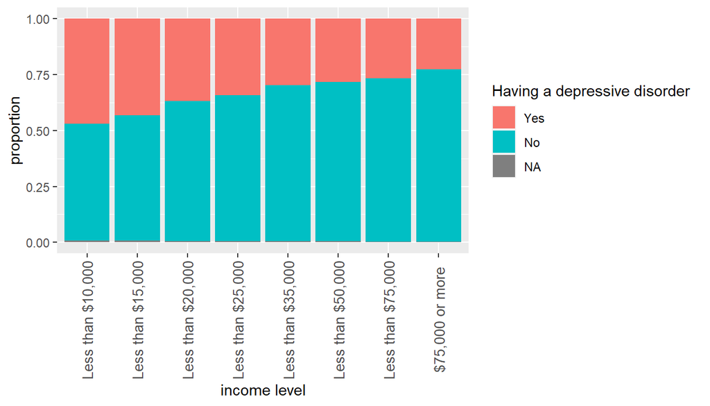

```r
ggplot(data = my_Data4 , aes(income2 , fill=addepev2)) + geom_bar(position = "fill") + theme(axis.text.x = element_text(angle =90, size = 10, vjust = 0.5)) + xlab("income level") + ylab("proportion") + scale_fill_discrete(name="Having a depressive disorder ")
```

the plot shows that by increasing the outcome the percentage of people having disorders tends to be less which shows that there may be a correlation between the two variables we can know more by looking at our summary numbers

```r
Table <- my_Data4 %>%
group_by(income2, addepev2) %>%
summarize(Sum = n()) %>%
spread(addepev2, Sum) %>%
mutate(Sum = Yes+No, `% Yes` = round(Yes/Sum*100, digits =1))
colnames(Table)[1] <- "Income Level"
pandoc.table(Table, caption = " Summary Statistics for if Respondent has ever been diagnosed a depressive disorder by Income Level", justify = "center")
```

```
##
## ----------------------------------------------------------
##    Income Level       Yes     No     <NA>    Sum    % Yes
## ------------------- ------- ------- ------ ------- -------
##  Less than $10,000   7750    8639    143    16389   47.3
##
##  Less than $15,000   7300    9443    116    16743   43.6
##
##  Less than $20,000   7405    12674    93    20079   36.9
##
##  Less than $25,000   7789    14903   132    22692   34.3
##
##  Less than $35,000   7375    17232   128    24607    30
##
##  Less than $50,000   8417    21074   140    29491   28.5
##
##  Less than $75,000   8160    22373    93    30533   26.7
##
##   $75,000 or more    11190   38256   136    49446   22.6
## ----------------------------------------------------------
##
## Table:  Summary Statistics for if Respondent has ever been diagnosed a depressive disorder by Income Level
```

this table shows that the higher income level the less yes answers we receive for the depressive disorder question there maybe a correlation between these two variables